# Relational Data

AREC 280 - Harvesting Big Data

James Archsmith

University of Maryland

2026-10-20

## Today’s Goals

Today we will

- Discuss concepts in **relational data**
- consider applications for relational data methods in this class
- Perform a basic join of two datasets

We will use the CRU **and** FAO data

`AGNR-AREC280_Fall2026/Data/CRU/parquet`

`AGNR-AREC280_Fall2026/Data/FAO/parquet`

## Loading Datasets

First load the CRU and FAO data from Parquet Files

```r
# Load required libraries
library(tidyverse)
library(arrow)
# Load the full fao dataset
read_parquet(
  file.path(data_path,"FAO","parquet","FAO_crop_livestock.parquet")
) -> faostat

read_parquet(
  file.path(data_path,"CRU","parquet","tmp_w_ISO3.parquet")
) -> cru_tmp
```

# Leveraging our existing data

## Using these data together

We’ve become familiar with two datasets so far

## Questions in Agriculture, Climate, and Weather

There are many questions we can thing about addressing:

- How have changing weather patterns impacted agricultural productivity?
- Which places/crops have been the most impacted by changes in climate over time?
- Which climate factors have the largest impacts on agricultural productivity?

How can we use the data we have now to answer these questions?

## Combining Data

The datasets you’ve used so far

- Contain different components we would need to answer these questions
- Difficult to leverage the data when they are in separate files
- Better to have a single file combining both weather and productivity
- These data files are created and maintained by different people

What can we do?

## Combining Data

CRU Columns

```
Year
Country
Variable
Period
Value
Country_Clean
ISO3
```

FAO Columns

```
ISO3166_1
Area
ItemCode
Item
Area Code
Item Code
Element Code
Element
Year Code
Year
Unit
Value
Flag
Note
ISO3
```

How might you combine these files?

## Combining Data

FAO and CRU have things in common

- Data for each country (`Country` or `Area`)
- Data for many years (`Year`)

Suppose we matched up observations for each country and year

- What problems might we run in to?

# Matching Text Data

## Challenges - Matching Text Data

Consider the United States

- What value does CRU use in `Country` to denote the United States?
  - `USA`
- What value foes FAO use in `Area` to denote the United States?
  - `United States of America`

Does this pose a challenge for combining these data files?

## Joins on Text Data

There are multiple ways to write out the name of each country

- Matching between these datasets requires knowing when countries are identical
- R doesn’t infer meaning from text, sequences of `0/1` values
  - Values match when sequences are **identical**
- When different datasets use different conventions you need to know how to resolve the conflicts
- This is generally a problem with freeform text data

In practice what can you do?

## Crosswalks for Joins

When combining files using text columns you frequently construct a **crosswalk**

- A data file separate from the files you are combining
- Contains two columns
- Each row matches names from one file to names from another
- When you combine the data, use the crosswalk in between

## Crosswalks for Joins

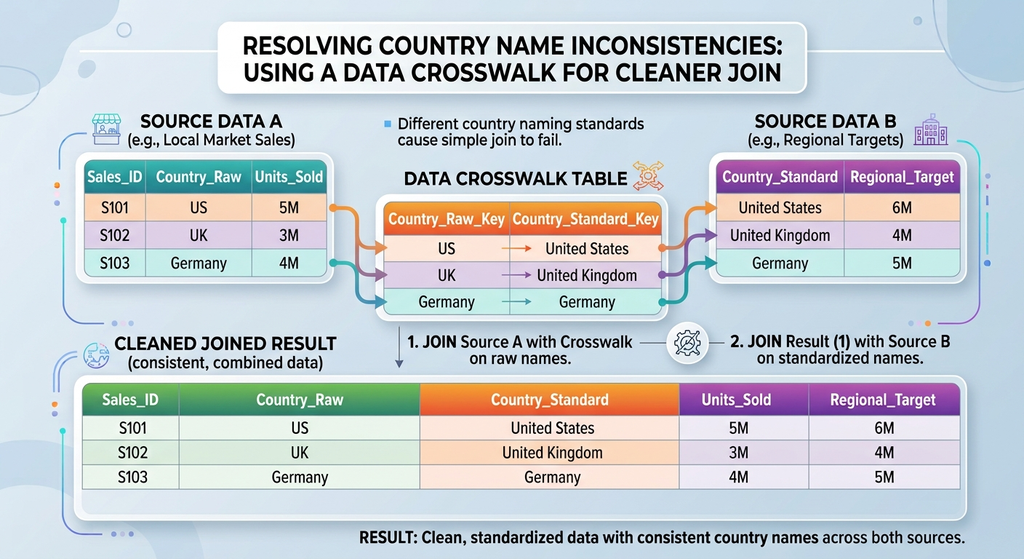

## Standardization

Instead of making a crosswalk, you can standardize text fields

- Choose an objective, uniform way of representing information in the text field
- Each unique entity has *exactly one* representation under your standard
- Anyone who follows your standard can determine what that representation is
- Standardized text fields can be joined without a crosswalk

## Best practices for text data

Crosswalks require that you

- Examine all the cases in your data
- Check that a crosswalk entry exists for each
- Reevalutate as your data are updated

## Best practices for text data

Standardization requires that you

- Decide on a clear, objective standard
- Ensure all entries in the column align with the standard
- Confirm data aligns with the standard as it is updated

## Standardizing Country Names

How should we standardize country names?

- Countries can have multiple ways of referring to themselves
- Multiple ways to spell some country names
- Proper names or common names?
- What if a country’s name changes?

A lot of decisions! It would be nice if someone made them for us

## Standardizing Country Names

A best practice when compiling country data is to use [ISO 3166 Country Codes](https://www.iso.org/iso-3166-country-codes.html)

- A **standard** created by the International Standards Organization
- Country codes are defined in ISO 3166
- Codes uniquely identify a specific country
- Each country has exactly one code of each type
- Two flavors (Alpha-2, Alpha-3)

## Standardized Country Names in FAO an CRU

- The original CRU data do not provide ISO country codes
- The FAO data provide numeric codes that are not in common use
- I have added a column named `ISO3` to each of the Parquet files
- Contains the ISO 3166 Alpha-3 code for each country
- Some regions in the data are not countries and do not have an ISO3 code
  - These have `NA` for `ISO3`

## Advantages of ISO 3166 Country Codes

- ISO 3166 provides an objective standard for identifying countries
- Anyone who wants to standardize country references knows which codes to use
- Unambiguously identify countries
- If you add ISO 3166 codes, easy to join any other dataset using ISO 3166 codes
- You don’t need to talk to the creator of the dataset to make this work

## Combining Data

FAO and CRU have things in common

- Data for each country (`Country` or `Area`)
- Data for many years (`Year`)

Suppose we matched up observations for each country and year

- What problems might we run in to?

# Cross Joins

## Combining Data - Cross Joins

Suppose we match the CRU and FAO data on `ISO3` and `Year`

- Think about just the United States in 1990
- What observatons in the CRU data will we have?
- What observations in the FAO data will we have?

## Combining Data - Cross Joins

Suppose we match the CRU and FAO data on `ISO3` and `Year`

- Think about just the United States in 1990
- What observations in the CRU data will we have?
  - One observation for each month, season, and an annual observation
- What observations in the FAO data will we have?
  - One observation for each commodity-measurement

What happens when we try to match observations between these two datasets?

## Cross Joins

The **join** commands we’ve covered for this class are *greedy*

- Look at the provided matching columns for observations with identical values
- Form *all possible matches* between the datasets
- This is a many-to-many or **cross join**
- Can lead to new datasets with many more observations that you expect

## Cross Join Example

[figure not shown]

Cross Join Example

## Cross Join Problems

Cross joins can be problematic

- Can lead to double-counting of information
- Throw off calculations when aggregating
- Explode memory usage

## Avoiding Many-to-Many Joins

There are some best practices for avoiding many-to-many joins

- Aim for joins that are `1:1`,`1:m` or `m:1`
- In one table, each row is uniquely identified by the matching columns
- If the above doesn’t hold, understand why

# Joins in R

## Joining Data Frames in R

Perform joins in R using

`join_*(<left_df>,<right_df>,by=<relationships>)`

- `<left_df>` - The “left” data frame
- `<right_df>` - The “right” data frame
- `<relationships>` - Vector of relationships
  - Columns that define how to match observations
  - Column names must be in quotes
  - Form a match whenever relationships have identical values

## Types of Joins

R has the following primary types of joins

- `inner_join` keep only observations that match in both data frames
- `left_join` keep all observations from the left data frame and matches from the right
- `right_join` keep all observations from the right data frame and matches from the left
- `full_join` keep all observations from both left and right data frame

## Types of Joins

R has the following additional joins

- `semi_join` keep all observations from the left data frame that have a match in the right
  - Does not duplicate observations from the left data frame
  - Does not include columns from the right data frame
- `anti_join` keep all observations from the left data frame that **do not** have a match in the right
  - Does not duplicate observations from the left data frame
  - Does not include columns from the right data frame
  - Useful for tracking down join errors

## Other Useful Arguments

Sometimes column names overlap between your files

- Both FAO and CRU contain a `Value` column (and it’s the most important!)
- Column names must be unique
- By default R will disambiguate the columns by appending
  - `.x` to the column name from the left table
  - `.y` to the column name from the right table
- Alternatively use

`suffix=c("<left_suffix>","<right_suffix>")`

## Performing a Join

Implement the following steps to join the FAO and CRU data

- Filter the CRU data to include only annual mean temperature (`Period == "ANN"`)
- Filter the FAO data to include only Avocado yield (`Item == "Avocados" & Element == "Yield"`)
- Remove observations with `NA` values of ISO3
- Join the datasets by `ISO3` and `Year` (which join?)
  - Is there a problem with column names?
- Create a scatter plot of average temperature against yeild
  - Color code dots by country

## Example Join

```r
cru_tmp |>
  # Filter to annual temperatures
  filter(Period == "ANN") |>
  # Drop NA ISO3
  drop_na(ISO3)-> cru_temp_ann

faostat |>
  # Filter to Avocado Yields
  filter(Item == "Avocados") |>
  filter(Element == "Yield") |>
  # Drop NA ISO3
  drop_na(ISO3) -> fao_avocado

# Join
cru_temp_ann |>
  inner_join(
    fao_avocado,
    by=c("ISO3","Year"),
    # Both datasets have "Value" columns. Disambiguate
    suffix=c("_cru","_fao")
  ) -> cru_fao

ggplot(data=cru_fao,aes(x=Value_cru,y=Value_fao)) +
  geom_point(aes(color=ISO3)) +
  theme_bw() +
  labs(
    x="Annual Average Temperature (C)",
    y="Yeild (mt/ha)",
    title="Avocado Yeilds by Country",
    color="Country"
  ) +
  scale_color_viridis_d()
```

[figure not shown]

## Next Class

- Advanced Joins
  - The `join_by()` syntax
  - Rolling Joins